# RNA sequence analysis by Limma voom

## Hierarchical clustering with heatmaps

An alternative to `plotMDS` for examining relationships between samples is using hierarchical clustering. Heatmaps are a nice visualisation to examine hierarchical clustering of your samples. We can do this using the `heatmap.2` function from the *gplots* package. In this example `heatmap.2` calculates a matrix of euclidean distances from the logCPM (`logcounts` object) for the 500 most variable genes. (Note this has more complicated code than plotting principle components using `plotMDS`.)

```r
# We estimate the variance for each row in the logcounts matrix
var_genes <- apply(logcounts, 1, var)
head(var_genes)
```

```
## 0610007C21Rik 0610007L01Rik 0610007P08Rik 0610007P14Rik 0610007P22Rik
##    0.19994898    0.05958934    0.32209151    0.74415571    0.53933826
## 0610009B22Rik
##    0.52314880
```

```r
# Get the gene names for the top 500 most variable genes
select_var <- names(sort(var_genes, decreasing=TRUE))[1:500]
head(select_var)
```

```
## [1] "Xist"  "Ddx3y" "Ncan"  "H19"   "Tnc"   "Tsix"
```

```r
# Subset logcounts matrix
highly_variable_lcpm <- logcounts[select_var,]
dim(highly_variable_lcpm)
```

```
## [1] 500  47
```

```r
head(highly_variable_lcpm)
```

```
##       M_P60_Sal_4    F_E18_1  M_E18_1   F_E18_3    M_E18_4   F_P14_1   F_P14_2
## Xist   1.73613212 11.2929626 3.912749 11.565861 7.08081474 11.528590 11.397702
## Ddx3y  7.67295795  0.9246783 7.080410  1.048404 0.02671539  1.736104  1.600986
## Ncan   0.56679938  9.0404600 9.673655  7.804281 6.14557066  3.585419  4.888941
## H19    0.02671539  9.6144091 7.725563  8.069605 9.49840095  1.121027  1.940893
## Tnc    0.02671539  9.1782575 9.879362  8.402794 5.38698726  2.765604  3.418163
## Tsix   0.95886301  7.4233714 1.511114  7.773471 2.63570343  7.708446  7.052977
##           F_P14_3   F_P14_4   F_P14_5     F_P14_6   F_P14_7    F_P14_8
## Xist  11.36300493 11.488611 10.818100 11.42024361 11.753362 11.3043672
## Ddx3y  0.02671539  0.766863  0.622964  0.02671539  2.133574  0.9195469
## Ncan   6.23177322  3.941020  3.642505  4.73394030  4.408354  2.8913122
## H19    2.20574202  1.253651  2.513693  0.02671539  2.133574  1.1259583
## Tnc    4.95986372  1.253651  2.862915  3.36805788  3.741245  1.6113120
## Tsix   6.91865694  7.680876  7.136882  6.98473417  7.617948  7.1421430
##           F_P14_9  F_P14_10   M_P4_1    F_P4_2     F_P4_3      F_P4_4
## Xist  11.22938690 11.423284 4.868099 11.941425 11.7303714 11.62273868
## Ddx3y  0.02671539  3.992099 7.860865  1.435233  0.4697579  0.02671539
## Ncan   2.88972997  3.353024 9.089244  8.881768  8.4557106  8.73258006
## H19    0.43844644  1.222100 5.067825  6.698196  5.9062837  6.21198761
## Tnc    2.33803607  2.030367 8.659236  8.184560  7.7909229  8.17933916
## Tsix   7.02849732  7.527981 1.672108  7.987855  7.7399374  7.73256701
##       F_P60_Sal_1 F_P60_Sal_2 F_P60_Sal_3 F_P60_Sal_4 F_P60_Sal_5 M_P60_Sal_5
## Xist  11.32877620 10.52651482 10.76803306 11.18493448 11.03941154  3.96279442
## Ddx3y  3.01492723  0.02671539  4.89767508  1.13472362  1.12157300  7.80956379
## Ncan   0.42202247  1.04497978  3.15484900  0.02671539  0.02671539  0.02671539
## H19    0.02671539  0.02671539  0.02671539  1.13472362  0.02671539  0.53340003
## Tnc    0.73198148  0.02671539  1.13871801  0.02671539  1.12157300  0.02671539
## Tsix   7.26555951  6.58618809  6.78996944  7.11620290  7.00343644  1.20453391
##       F_P60_Sal_7     F_E18_2   M_E18_2    M_E18_3   M_P14_1   M_P14_2
## Xist  10.90034895 10.12859323  4.186963 1.99295592 2.9376416 4.0051552
## Ddx3y  0.97270141  0.02671539  7.421574 6.73014471 8.9454661 8.7574620
## Ncan   0.02671539  9.32967601  9.042180 7.85131501 2.8572640 4.3521452
## H19    0.02671539  9.42374695 10.129089 9.44050933 1.1790216 0.9919863
## Tnc    1.53920031  9.39212653  9.366685 8.18991446 1.8113778 3.4223680
## Tsix   6.75047978  6.38862768  1.114389 0.02671539 0.8867852 1.5651842
##          M_P14_3   M_P14_4    M_P14_5    M_P14_6  M_P14_7    M_P14_8    M_P14_9
## Xist  2.27030043 3.1434082 2.37898964 2.05311087 1.673146 2.16346068 1.91845873
## Ddx3y 8.59900999 8.6533382 8.21923646 8.47955428 8.514305 8.47488552 8.48079890
## Ncan  5.27047112 5.2162285 5.97081747 6.03853271 5.325025 2.63470423 0.95545425
## H19   0.02671539 1.9819313 0.02671539 2.05311087 3.278030 0.02671539 0.02671539
## Tnc   3.69053110 3.8776600 4.23239832 3.75957387 3.918988 2.16346068 0.02671539
## Tsix  0.57955035 0.9970143 0.02671539 0.02671539 1.073060 0.02671539 0.02671539
##         M_P14_10     F_P4_1    M_P4_2   M_P4_3    M_P4_4 M_P60_Sal_1
## Xist  2.37380933 11.9050391 2.9264276 4.211328 3.0585247   3.8343561
## Ddx3y 8.41115656  0.5028741 8.1569867 7.631918 7.6708311   8.5503314
## Ncan  1.42462419  8.9406940 8.8222562 8.768186 8.2627856   1.2019736
## H19   0.88874748  6.0432719 6.4363791 5.543456 4.9197566   0.5320416
## Tnc   0.88874748  8.5902883 8.1658333 7.819771 7.8268140   1.8409237
## Tsix  0.02671539  7.8434052 0.5435895 1.651018 0.7514329   1.4477514
##       M_P60_Sal_2 M_P60_Sal_3 F_P60_Sal_6
## Xist   3.66486216  1.84429813 10.15987965
## Ddx3y  7.59490446  7.64827146  0.02671539
## Ncan   0.02671539  0.02671539  0.02671539
## H19    0.41570553  1.35723971  0.02671539
## Tnc    0.72177644  0.02671539  0.02671539
## Tsix   0.97414173  0.02671539  6.21787427
```

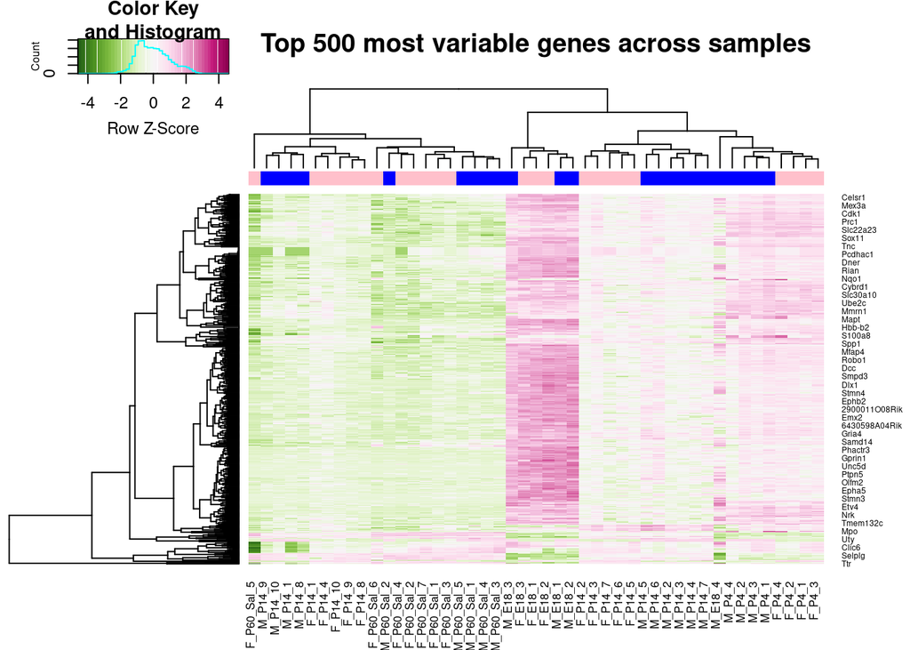

```r
library(RColorBrewer)
library("gplots")
## Get some nicer colours
mypalette <- brewer.pal(11,"PiYG")
morecols <- colorRampPalette(mypalette)
# Set up colour vector for celltype variable
col.cell <- c("pink","blue")[sampleinfo$Sex]

# Plot the heatmap
heatmap.2(highly_variable_lcpm,col=rev(morecols(50)),trace="none", main="Top 500 most variable genes across samples",ColSideColors=col.cell,scale="row")
```

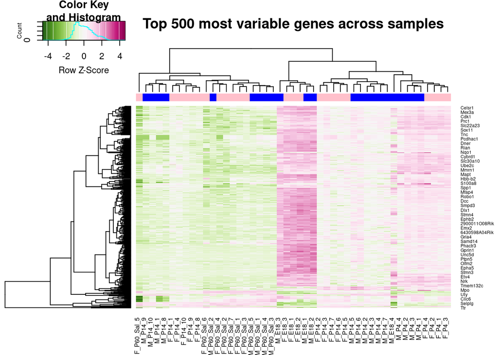

```r
# Save the heatmap

heatmap.2(highly_variable_lcpm,col=rev(morecols(50)),trace="none", main="Top 500 most variable genes across samples",ColSideColors=col.cell,scale="row")
```

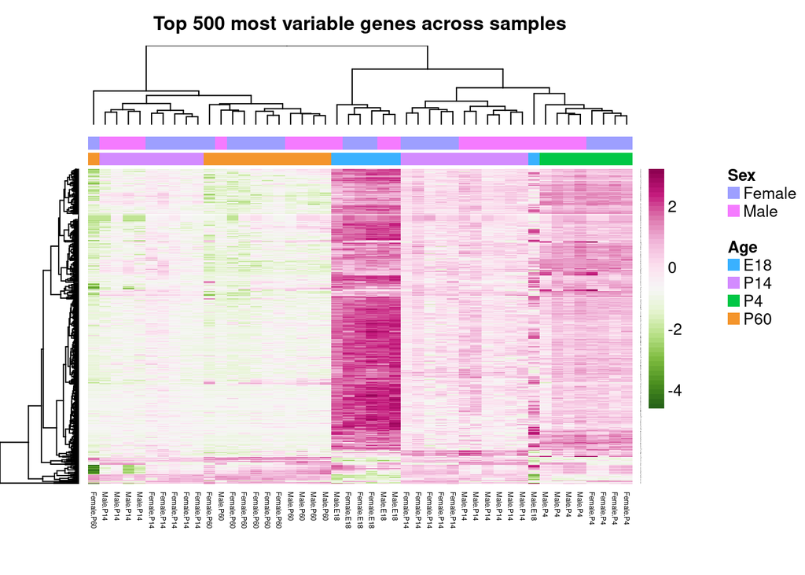

```r
library(NMF)
mypalette <- brewer.pal(11,"PiYG")
morecols <- colorRampPalette(mypalette)
aheatmap(highly_variable_lcpm,col=rev(morecols(50)),main="Top 500 most variable genes across samples",annCol=sampleinfo[, 2:3],labCol=group, scale="row")
```

# Normalisation for composition bias

TMM normalization is performed to eliminate composition biases between libraries (Mark D. Robinson and Oshlack 2010). This generates a set of normalization factors, where the product of these factors and the library sizes defines the effective library size. The `calcNormFactors` function calculates the normalization factors between libraries. TMM normalisation (and most scaling normalisation methods) scale relative to one sample.

```r
# Apply normalisation to DGEList object
y <- calcNormFactors(y)
```

This will update the normalisation factors in the `DGEList` object (their default values are 1). Take a look at the normalisation factors for these samples.

```r
y$samples
```

```
##                  group lib.size norm.factors
## M_P60_Sal_4   Male.P60  2161954    1.0014492
## F_E18_1     Female.E18  2273832    1.2763390
## M_E18_1       Male.E18  1637900    1.3055472
## F_E18_3     Female.E18  1905575    1.2332246
## M_E18_4       Male.E18  1347164    0.7493055
## F_P14_1     Female.P14  1729611    0.8875617
## F_P14_2     Female.P14  2481612    0.9148976
## F_P14_3     Female.P14  2225663    0.9934222
## F_P14_4     Female.P14  2928785    0.8965693
## F_P14_5     Female.P14  1918109    1.0245631
## F_P14_6     Female.P14   859638    0.9911483
## F_P14_7     Female.P14   890380    0.9876273
## F_P14_8     Female.P14  3437085    0.8315615
## F_P14_9     Female.P14  2972168    0.8439532
## F_P14_10    Female.P14  2282805    0.8622536
## M_P4_1         Male.P4  1844922    1.2070764
## F_P4_2       Female.P4  2373082    1.1116095
## F_P4_3       Female.P4  2730841    1.1279057
## F_P4_4       Female.P4  1955915    1.1208350
## F_P60_Sal_1 Female.P60  3114150    0.8651576
## F_P60_Sal_2 Female.P60   957259    0.9335680
## F_P60_Sal_3 Female.P60  2535572    0.8957692
## F_P60_Sal_4 Female.P60   849562    0.9394901
## F_P60_Sal_5 Female.P60   864190    0.9561111
## M_P60_Sal_5   Male.P60  2332923    0.9479705
## F_P60_Sal_7 Female.P60  1059520    0.9932473
## F_E18_2     Female.E18  2283521    1.3843438
## M_E18_2       Male.E18  2617012    1.3483545
## M_E18_3       Male.E18  2701030    1.1586621
## M_P14_1       Male.P14  2408586    0.8251292
## M_P14_2       Male.P14  2061360    0.8835496
## M_P14_3       Male.P14  2102191    0.8955353
## M_P14_4       Male.P14  1023356    1.0244327
## M_P14_5       Male.P14   956242    1.0365651
## M_P14_6       Male.P14   958064    1.0600435
## M_P14_7       Male.P14   921486    1.0402466
## M_P14_8       Male.P14  1155669    0.9177313
## M_P14_9       Male.P14  1086364    0.9033500
## M_P14_10      Male.P14  2401308    0.8726544
## F_P4_1       Female.P4  2510391    1.1705090
## M_P4_2         Male.P4  2278396    1.1481307
## M_P4_3         Male.P4  1885133    1.1486958
## M_P4_4         Male.P4  3008536    1.0763159
## M_P60_Sal_1   Male.P60  2340360    0.9257675
## M_P60_Sal_2   Male.P60  3171972    0.8802944
## M_P60_Sal_3   Male.P60  1943939    0.9908049
## F_P60_Sal_6 Female.P60   790033    0.8869306
```

```r
save(group,y,logcounts,sampleinfo,file="/home/nisha/Desktop/Richa/combine_tutorial_limma/day1objects.Rdata")
```

# Differential expression with limma-voom

There are a number of packages to analyse RNA-Seq data. The *limma* package (Ritchie et al. 2015) (since version 3.16.0) offers the `voom` function, which transforms the read counts into logCPMs while taking into account the mean-variance relationship in the data. After vooming, users can apply a linear model to the voom transformed data to test for differentially expressed genes, using standard *limma* commands.

The first is the design matrix which indicates in effect which RNA samples have been applied to each array. The second is the contrast matrix which specifies which comparisons you would like to make between the RNA samples. For very simple experiments, you may not need to specify the contrast matrix.

## **Create the design matrix**

```r
# Specify a design matrix without an intercept term
design <- model.matrix(~ 0 + group)
design
```

```
##    groupFemale.E18 groupFemale.P14 groupFemale.P4 groupFemale.P60 groupMale.E18
## 1                0               0              0               0             0
## 2                1               0              0               0             0
## 3                0               0              0               0             1
## 4                1               0              0               0             0
## 5                0               0              0               0             1
## 6                0               1              0               0             0
## 7                0               1              0               0             0
## 8                0               1              0               0             0
## 9                0               1              0               0             0
## 10               0               1              0               0             0
## 11               0               1              0               0             0
## 12               0               1              0               0             0
## 13               0               1              0               0             0
## 14               0               1              0               0             0
```

[output cut: 86 more lines]

```r
## Make the column names of the design matrix a bit nicer
colnames(design) <- levels(group)
design
```

```
##    Female.E18 Female.P14 Female.P4 Female.P60 Male.E18 Male.P14 Male.P4
## 1           0          0         0          0        0        0       0
## 2           1          0         0          0        0        0       0
## 3           0          0         0          0        1        0       0
## 4           1          0         0          0        0        0       0
## 5           0          0         0          0        1        0       0
## 6           0          1         0          0        0        0       0
## 7           0          1         0          0        0        0       0
## 8           0          1         0          0        0        0       0
## 9           0          1         0          0        0        0       0
## 10          0          1         0          0        0        0       0
## 11          0          1         0          0        0        0       0
## 12          0          1         0          0        0        0       0
## 13          0          1         0          0        0        0       0
## 14          0          1         0          0        0        0       0
```

[output cut: 86 more lines]

## **Voom transform the data**

Once we have our design matrix ready to go, we can perform our voom transformation. Voom will automatically adjust the library sizes using the `norm.factors` already calculated. The voom transformation uses the experiment design matrix, and produces an `EList` object. We can add `plot=TRUE` to generate a plot of the mean-variance trend. This plot can also tell us if there are any genes that look really variable in our data, and if we’ve filtered the low counts adequately.

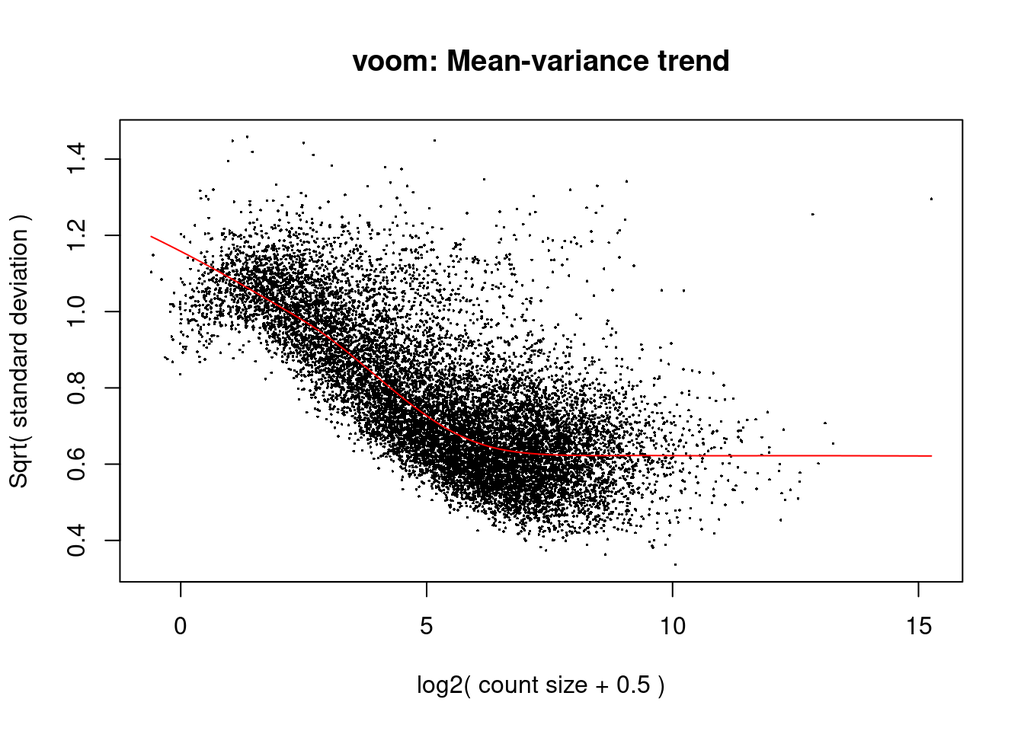

```r
par(mfrow=c(1,1))
v <- voom(y,design,plot = TRUE)
```

The voom normalised log2 counts can be found in v$E. Take a look at what is in the voom object.

```r
v
```

```
## An object of class "EList"
## $targets
##                  group lib.size norm.factors
## M_P60_Sal_4   Male.P60  2165087    1.0014492
## F_E18_1     Female.E18  2902181    1.2763390
## M_E18_1       Male.E18  2138356    1.3055472
## F_E18_3     Female.E18  2350002    1.2332246
## M_E18_4       Male.E18  1009437    0.7493055
## 42 more rows ...
##
## $E
##               M_P60_Sal_4  F_E18_1  M_E18_1  F_E18_3  M_E18_4  F_P14_1  F_P14_2
## 0610007C21Rik    6.623667 5.647738 6.446529 6.000957 8.918662 6.708062 6.478818
## 0610007L01Rik    6.511283 6.095857 5.419197 6.084750 5.997674 6.680840 6.671908
## 0610007P08Rik    5.686474 5.055319 4.532854 5.555240 3.510009 4.756672 5.439091
## 0610007P14Rik    4.189355 4.682031 5.691400 5.168217 7.330743 3.807897 3.598399
## 0610007P22Rik    2.839771 3.295752 4.207278 3.744617 5.831937 3.739184 2.675021
##                F_P14_3  F_P14_4  F_P14_5  F_P14_6  F_P14_7  F_P14_8  F_P14_9
## 0610007C21Rik 6.359111 6.648869 6.701263 6.579752 6.218890 6.139555 6.558945
## 0610007L01Rik 6.413706 6.610025 6.464098 6.579752 6.636678 6.667313 6.664771
## 0610007P08Rik 5.238990 5.138592 5.164857 5.534805 5.785379 4.742307 4.639033
## 0610007P14Rik 4.264676 3.873997 4.434697 4.360307 4.857892 3.824769 3.781773
## 0610007P22Rik 3.212837 3.161799 3.451570 2.038379 1.507395 3.266279 3.345674
##               F_P14_10   M_P4_1   F_P4_2   F_P4_3   F_P4_4 F_P60_Sal_1
## 0610007C21Rik 6.502788 5.905618 6.143619 6.280890 6.129677    6.853214
## 0610007L01Rik 6.411025 6.206866 6.580727 6.200375 6.652217    6.712233
## 0610007P08Rik 4.988792 5.645822 5.617396 5.601009 5.302210    5.841589
## 0610007P14Rik 3.953745 4.715287 4.655870 4.969465 4.856266    3.759951
## 0610007P22Rik 2.777895 3.130325 2.644982 3.158367 2.622469    2.213982
##               F_P60_Sal_2 F_P60_Sal_3 F_P60_Sal_4 F_P60_Sal_5 M_P60_Sal_5
## 0610007C21Rik    6.662036    6.646212    6.887500    6.641650    6.473332
## 0610007L01Rik    6.322061    6.620620    6.291041    6.373360    6.405693
## 0610007P08Rik    5.352015    5.408946    5.475004    5.206065    5.706696
## 0610007P14Rik    3.806046    4.292223    3.025697    3.667645    4.229986
## 0610007P22Rik    3.554508    2.571377    2.495182    2.082683    3.921036
##               F_P60_Sal_7  F_E18_2  M_E18_2  M_E18_3  M_P14_1  M_P14_2  M_P14_3
## 0610007C21Rik    6.909357 6.022532 5.668719 6.937113 6.753955 6.598544 6.386491
## 0610007L01Rik    6.647462 6.070856 5.586021 6.092122 6.813252 6.775265 6.727528
## 0610007P08Rik    5.335754 3.270275 4.529607 4.573199 4.951635 5.392407 5.185315
## 0610007P14Rik    4.759253 5.216054 4.981779 5.597204 3.563710 3.264303 3.868643
```

[output cut: 53 more lines]

```
## [1,] 6.565894 6.487228 6.619817 6.592107 6.640253 6.555674 5.944077
## [2,] 6.608008 6.552596 6.643389 6.578122 6.632527 6.536396 5.206136
## [3,] 6.317476 6.121320 6.470067 6.176854 6.407094 6.025387 3.166823
## [4,] 5.533688 5.117791 5.924025 4.153534 4.820360 3.839716 1.733537
## [5,] 2.399477 2.078568 2.826056 2.597436 3.151542 2.373077 1.061553
## 13363 more rows ...
##
## $design
##   Female.E18 Female.P14 Female.P4 Female.P60 Male.E18 Male.P14 Male.P4 Male.P60
## 1          0          0         0          0        0        0       0        1
## 2          1          0         0          0        0        0       0        0
## 3          0          0         0          0        1        0       0        0
## 4          1          0         0          0        0        0       0        0
## 5          0          0         0          0        1        0       0        0
## 42 more rows ...
```

```r
# What is contained in this object?
names(v)
```

```
## [1] "targets" "E"       "weights" "design"
```

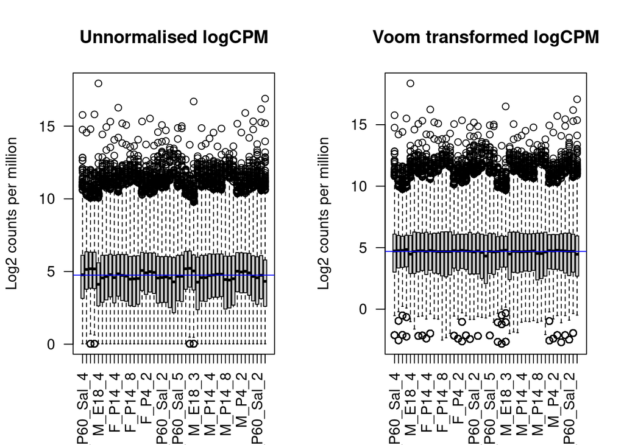

```r
par(mfrow=c(1,2))
boxplot(logcounts, xlab="", ylab="Log2 counts per million",las=2,main="Unnormalised logCPM")
## Let's add a blue horizontal line that corresponds to the median logCPM
abline(h=median(logcounts),col="blue")
boxplot(v$E, xlab="", ylab="Log2 counts per million",las=2,main="Voom transformed logCPM")
## Let's add a blue horizontal line that corresponds to the median logCPM
abline(h=median(v$E),col="blue")
```

### **Testing for differential expression**

Now that we have the voom transformed data we can use *limma* to test for differential expression. First we fit a linear model for each gene using the `lmFit` function in *limma*. `lmFit` needs the voom object and the design matrix that we have already specified, which is stored within the voom object.

```r
# Fit the linear model
fit <- lmFit(v)
names(fit)
```

```
##  [1] "coefficients"     "stdev.unscaled"   "sigma"            "df.residual"
##  [5] "cov.coefficients" "pivot"            "rank"             "Amean"
##  [9] "method"           "design"
```

`lmFit` estimates group means according to the design matrix, as well as gene-wise variances. There are a number of items stored in the `fit` object, most of which are specific to the statistical testing.

```r
cont.matrix <- makeContrasts(malevsfemale60 = Male.P60 - Female.P60,levels=design)
```

The contrast matrix tells *limma* which columns of the design matrix we are interested in testing our comparison. Note that here we have specified only one comparison to test, but we can specify as many as we want in one go

```r
cont.matrix
```

```
##             Contrasts
## Levels       malevsfemale60
##   Female.E18              0
##   Female.P14              0
##   Female.P4               0
##   Female.P60             -1
##   Male.E18                0
##   Male.P14                0
##   Male.P4                 0
##   Male.P60                1
```

Now we can apply the contrasts matrix to the `fit` object to get the statistics and estimated parameters of our comparison that we are interested in. Here we call the `contrasts.fit` function in *limma*.

```r
fit.cont <- contrasts.fit(fit, cont.matrix)
```

The final step is to call the `eBayes` function, which performs empirical Bayes shrinkage on the variances, and estimates moderated t-statistics and the associated p-values.

```r
fit.cont <- eBayes(fit.cont)
```

Check the dimensions of the fit object

```r
dim(fit.cont)
```

```
## [1] 13368     1
```

We can use the *limma* `decideTests` function to generate a quick summary of DE genes for the contrasts.

```r
summa.fit <- decideTests(fit.cont)
summary(summa.fit)
```

```
##        malevsfemale60
## Down                2
## NotSig          13362
## Up                  4
```

Similarly for Male.E18 vs Female.E18

```r
cont.matrix <- makeContrasts(malevsfemaleE18 = Male.E18 - Female.E18,levels=design)
fit.cont <- contrasts.fit(fit, cont.matrix)
fit.cont <- eBayes(fit.cont)
summa.fit <- decideTests(fit.cont)
summary(summa.fit)
```

```
##        malevsfemaleE18
## Down                 3
## NotSig           13361
## Up                   4
```

## For all

```r
contrast.matrix <- makeContrasts( Male.E18-Female.E18,Male.P4 -Female.P4,Male.P14-Female.P14,Male.P60-Female.P60, levels=design)
```

```r
fit2 <- contrasts.fit(fit, contrast.matrix)
```

```r
 fit2 <- eBayes(fit2)
```

```r
summa.fit2 <- decideTests(fit2)
summary(summa.fit2)
```

```
##        Male.E18 - Female.E18 Male.P4 - Female.P4 Male.P14 - Female.P14
## Down                       3                   2                     2
## NotSig                 13361               13362                 13362
## Up                         4                   4                     4
##        Male.P60 - Female.P60
## Down                       2
## NotSig                 13362
## Up                         4
```

```r
results <- decideTests(fit2)
```

### Venn diagram

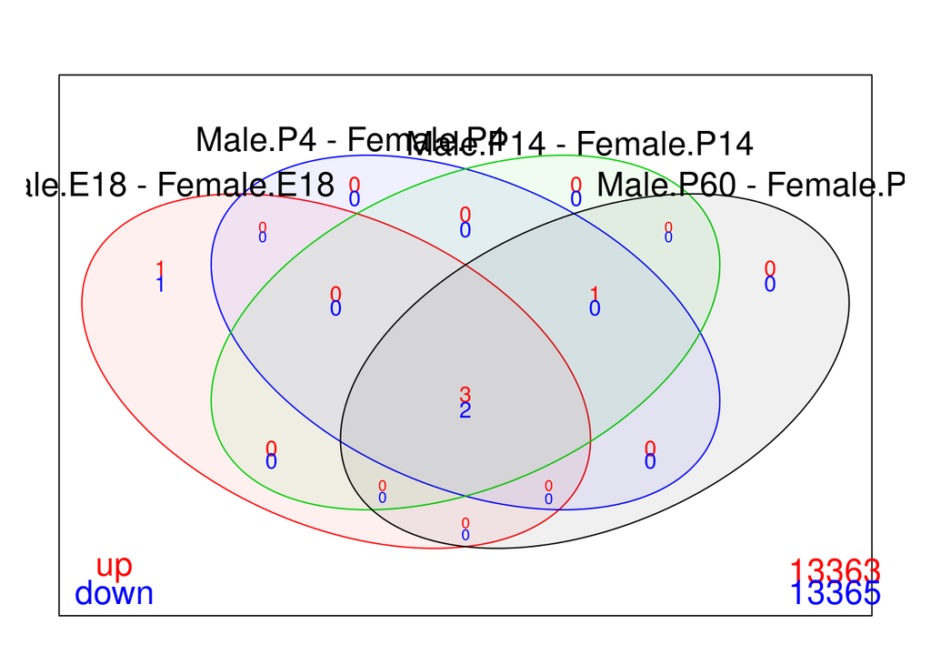

```r
vennDiagram(results,
    include=c("up", "down"),
    counts.col=c("red", "blue"),
    circle.col = c("red", "blue", "green3","black"))
```

# Writing out the results

## Plots after testing for DE

Let’s do a few plots to make sure everything looks good and that we haven’t made a mistake in the analysis. Genome-wide plots that are useful for checking are MAplots (or MDplots) and volcano plots. There are functions in limma for plotting these with `fit.cont` as input.